# Продвинутые темы - третий этап внешнего курса

## Смотрим вывод, после чего изменяем что-то в программе если вывод не соответствует приведенному примеру

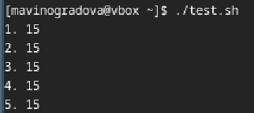

Сверяем вывод и пример

## Ознакамливаемся с шестнадцатым вопросом

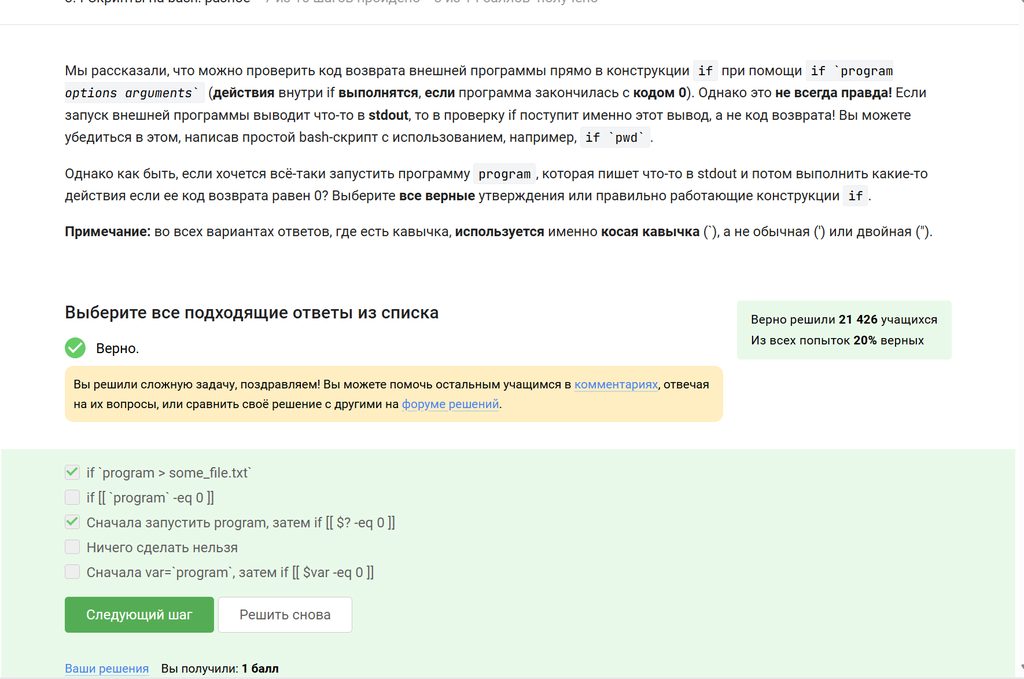

Смотрим текст вопроса

## Почему ответ верен:

1. if program > some_file.txt Перенаправление вывода (>) в файл позволяет if проверять только код возврата.
2. if [[ $? -eq 0 ]] $? хранит код возврата последней команды.

## Ознакамливаемся с семнадцатым вопросом

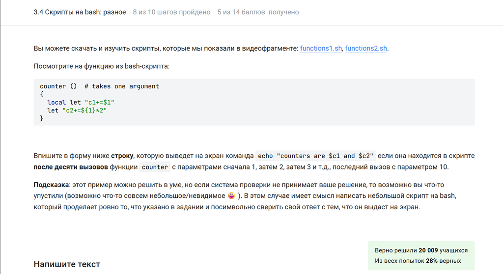

Смотрим текст вопроса

## Почему ответ верен: Пишем скрипт на bash

[figure not shown]

Пишем программу

## Смотрим вывод, его и вносим в ответ

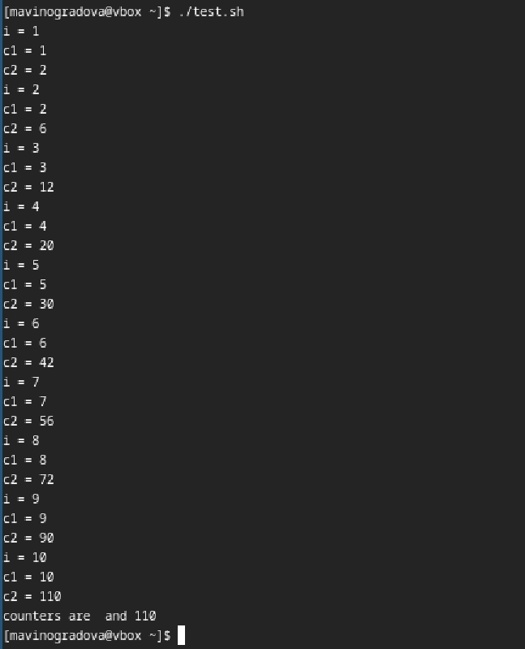

Проверяем вывод

## Ознакамливаемся с восемнадцатым вопросом

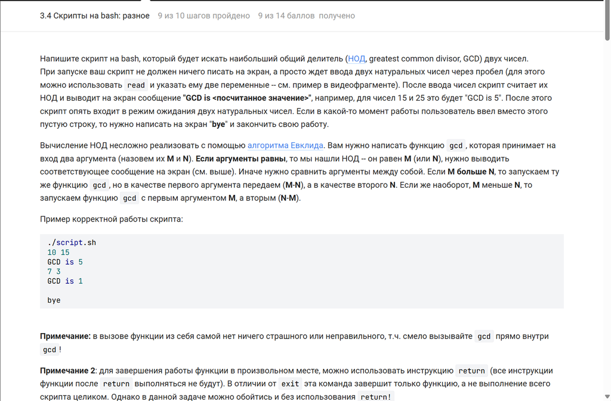

Смотрим текст вопроса

## Почему ответ верен: Пишем скрипт на bash

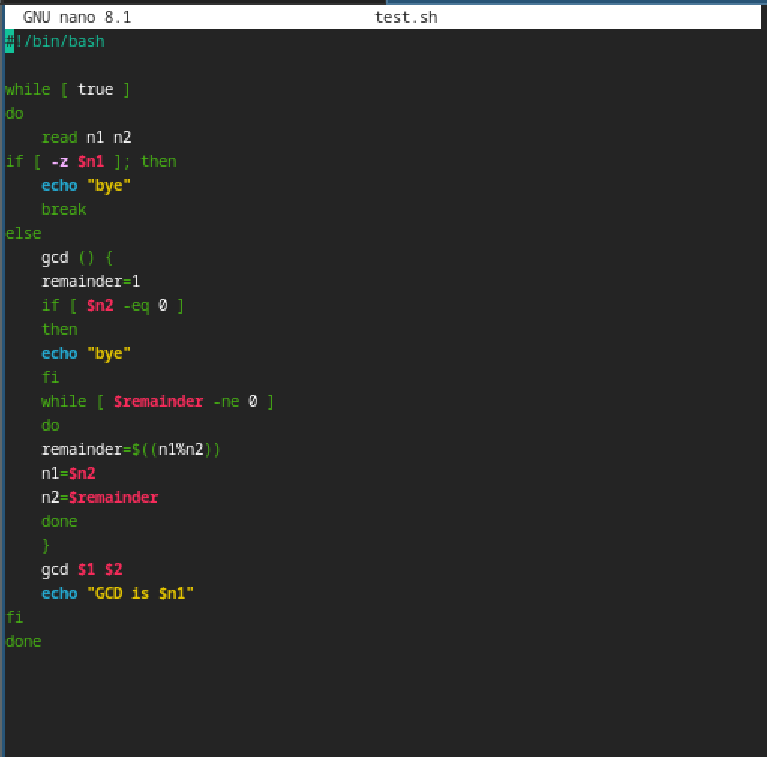

Пишем программу

## Смотрим вывод, после чего изменяем что-то в программе если вывод не соответствует приведенному примеру

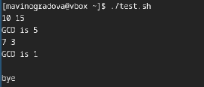

Сверяем вывод и пример

## Ознакамливаемся с девятнадцатым вопросом

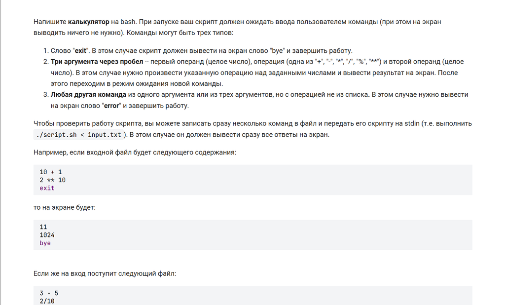

Смотрим текст вопроса

## Почему ответ верен: Пишем скрипт на bash

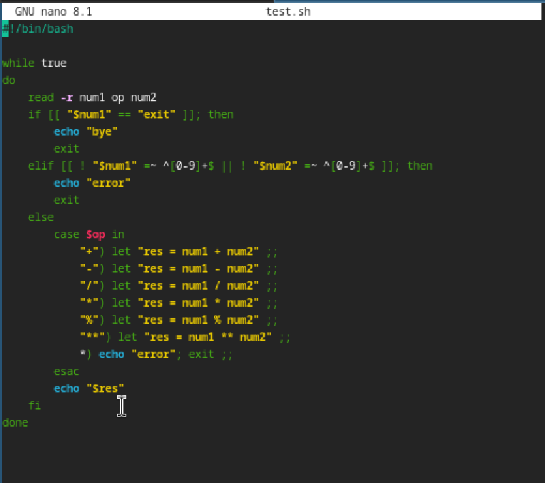

Пишем программу

## Смотрим вывод, после чего изменяем что-то в программе если вывод не соответствует приведенному примеру

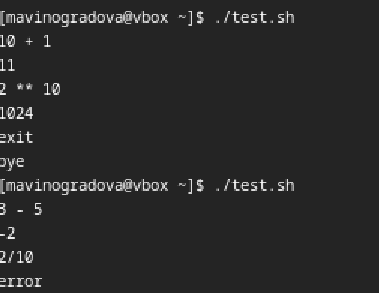

Сверяем вывод и пример

## Ознакамливаемся с двадцатым вопросом

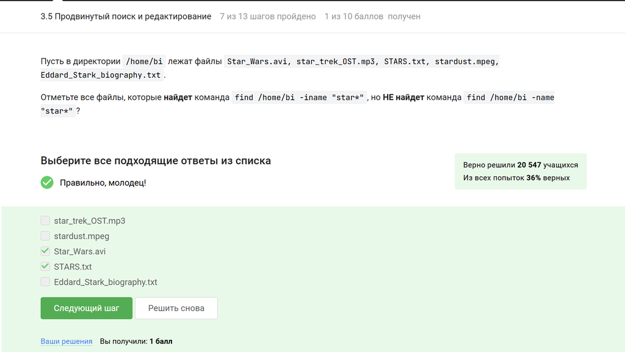

Смотрим текст вопроса

## Почему ответ верен:

Почему Star_Wars.avi и STARS.txt:

- -iname “star*” игнорирует регистр → находит Star*, STAR*.
- -name “star*” учитывает регистр → только star* (пропускает Star*, STAR*).

## Ознакамливаемся с двадцать первым вопросом

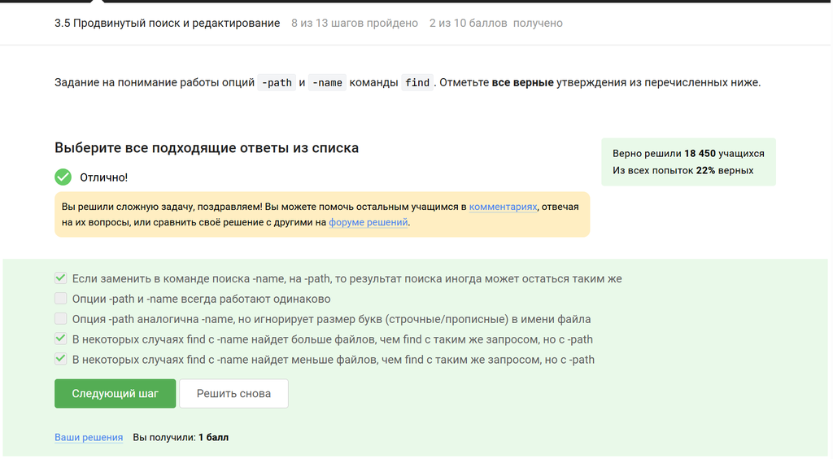

Смотрим текст вопроса

## Почему ответ верен:

- Результат может совпадать

  Если файлы лежат в корне директории (/home/file.txt), то -name “file.txt” и -path “/home/file.txt” дадут одинаковый результат.
- -name иногда находит больше/меньше

  -name проверяет только имя файла, а -path — полный путь.

## Ознакамливаемся с двадцать вторым вопросом

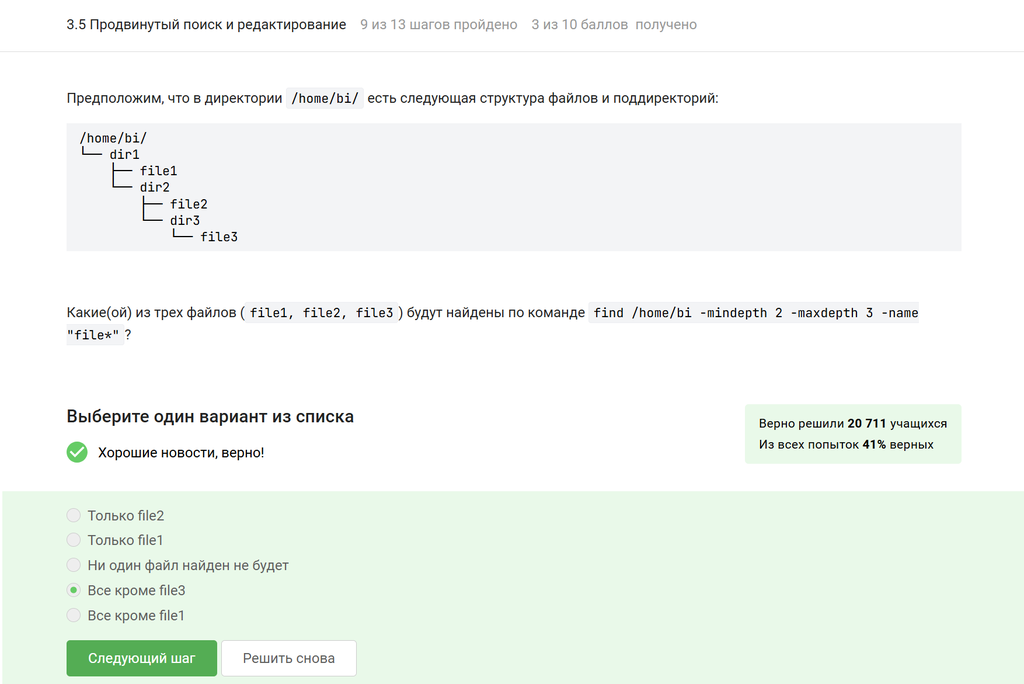

Смотрим текст вопроса

## Ознакамливаемся с двадцать третьим вопросом

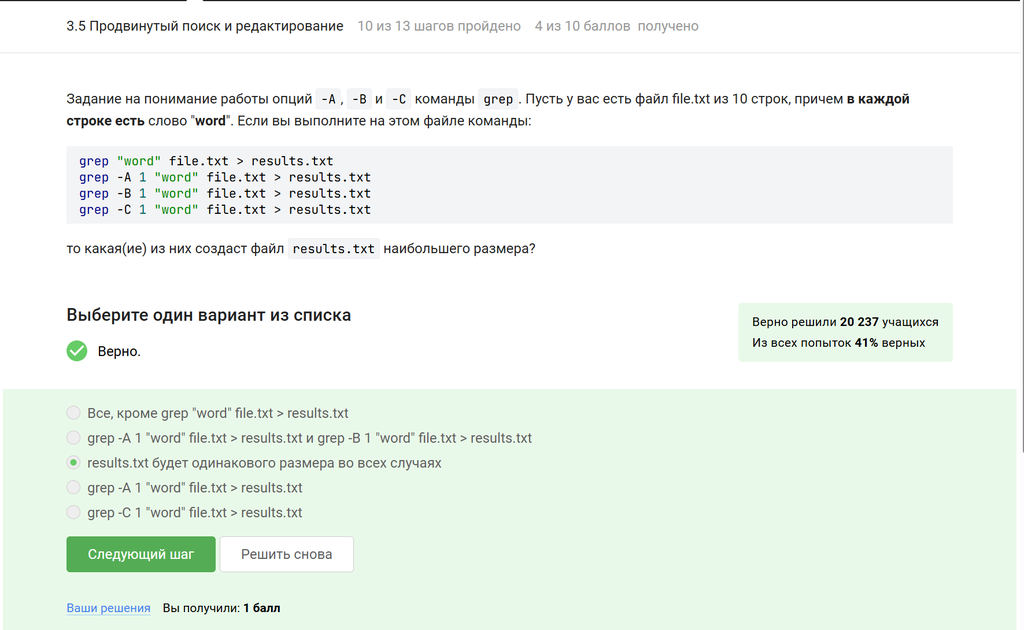

Смотрим текст вопроса

## Почему ответ верен:

1. Особенность файла: Так как слово “word” есть в каждой строке, то:
- Каждая строка является совпадением для grep.
- Опции -A, -B, -C добавляют контекст вокруг совпадений, но:
- Строки до/после совпадения уже сами являются совпадениями (из-за условия “слово есть везде”).
- Контекст не добавляет новых строк, так как все строки уже включены как основные совпадения.

## Ознакамливаемся с двадцать четвертым вопросом

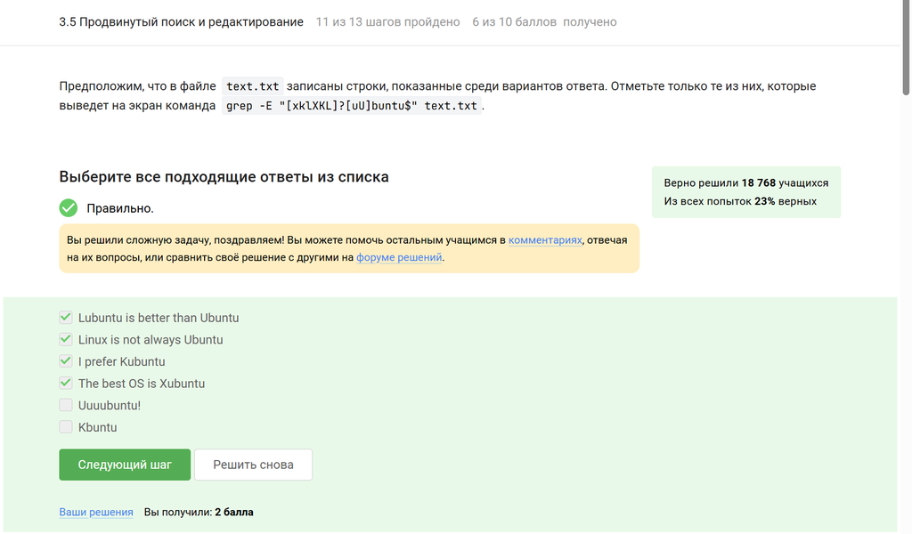

Смотрим текст вопроса

## Почему ответ верен: Пишем скрипт на bash и на практике проверяем все варианты ответа

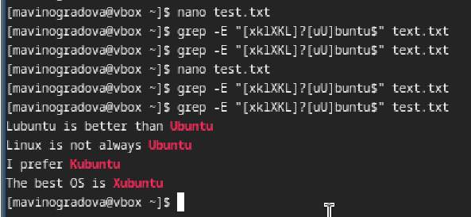

Практически проверяем каждый ответ

## Ознакамливаемся с двадцать пятым вопросом

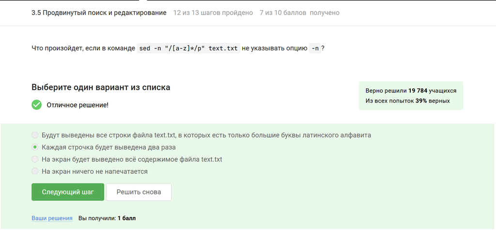

Смотрим текст вопроса

## Почему ответ верен:

1. Как работает sed без -n:

По умолчанию sed выводит все строки обрабатываемого файла (text.txt). Если встречается команда p (печать), строка выводится повторно.

2. Регулярное выражение /[a-z]*/:

[a-z]* означает «0 или больше букв латинского алфавита». Это выражение всегда совпадает (даже с пустой строкой!), так как: “*” включает «ноль символов». Даже строка 123 содержит «ноль букв», что считается совпадением.

3. Логика обработки: Для каждой строки (включая пустые):

sed автоматически выводит строку (стандартное поведение без -n). Если строка совпадает с /[a-z]*/ (а это всегда верно), команда p дополнительно печатает её ещё раз.

## Ознакамливаемся с двадцать шестым вопросом

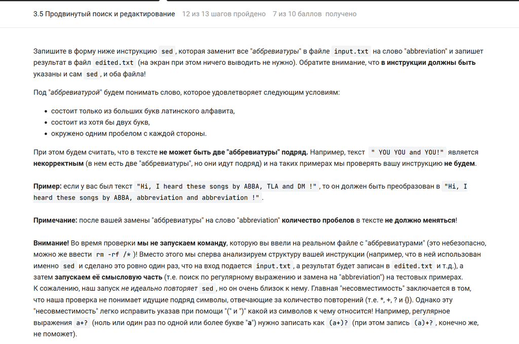

Смотрим текст вопроса

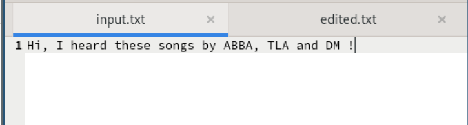

Создаем файлы и заполняем один из них

## Пишем инструкцию sed и выводим итог во второй созданный фай

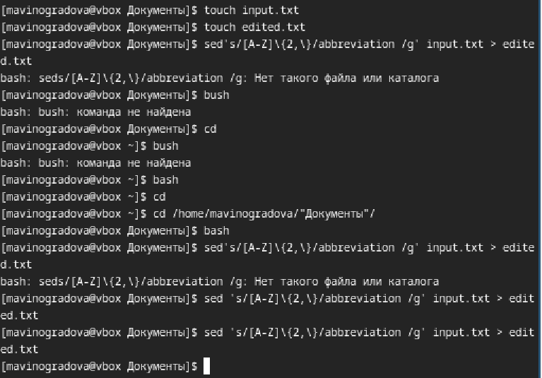

Пишем инструкцию

## Переходим во второй из созданных файлов и в нем проверяем результат

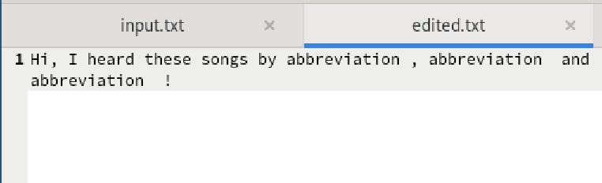

# Выводы

В ходе заключительного этапа курса я освоила продвинутые инструменты для работы в Linux: автоматизацию задач с помощью Bash-скриптов (условия, циклы, обработка ошибок), эффективное редактирование файлов в Vim (режимы, поиск, макросы) и применение мощных утилит командной строки (sed, awk, grep с контекстом, find). Эти навыки позволили уверенно работать с серверами, быстро обрабатывать данные и избегать рутинных операций. Теперь я готова применять знания в реальных проектах, таких как создание скриптов для развёртывания сервисов или анализа логов. Курс стал отличной основой для дальнейшего углубления в администрирование Linux.